# Data Viz 2: Mapping Areas and Context

## Learning Objectives

By the end of this practical lab you will be able to: * Map the attributes of areas including contextual points and lines using base R * Creating layered maps using ggplot2 * Creating layered maps using the tmap package

## Making maps in R

Like most analysis task within R there are a few different ways in we can make maps. In this practical lab we will introduce various ways in which we can map the attribute of areas and contextualize these to build a richer cartography. We will illustrate this through base R, and a series of packages including ggplot2 and tmap.

## Choropleth mapping in base R

Before we can create a map in R, we first need to import some spatial data. We will read in two shapefiles, the first containing polygons that will later be used to create a [choropleth map](https://en.wikipedia.org/wiki/Choropleth_map), and the second some street segments that will be used to provide context.

```r
#Load required package
library(sf)

# check wd
getwd()
```

```
## [1] "E:/Dropbox (Personal)/Auckland/Teaching/sem 1 2025/771/lab 1/Lab 1 _ 2024/2025"
```

```r
setwd("E:\\Dropbox (Personal)\\Auckland\\Teaching\\sem 1 2025\\771\\lab 1\\Lab 1 _ 2024\\2025")

#Read polygons (creates a simple features object)
LSOA <- st_read("./data/E06000042.shp")
#Read lines (creates a simple features object)
roads <- st_read("./data/Road.shp")
```

We can can use the plot() function which is built into base R to show the outlines of the polygons contained within the “LSOA” object.

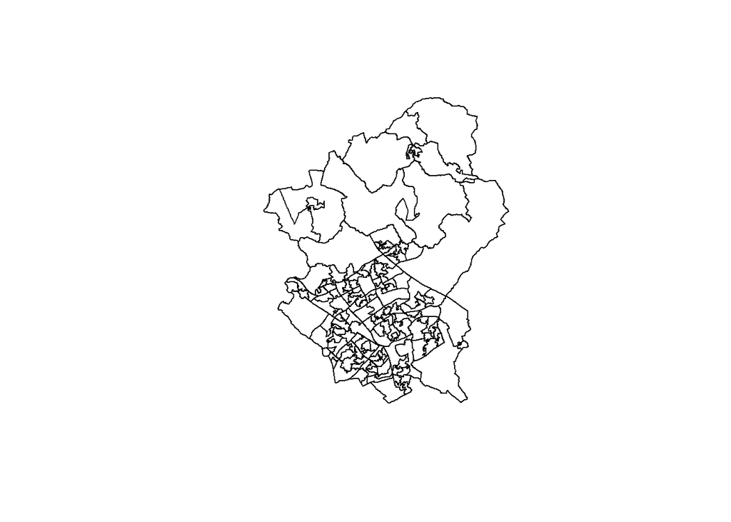

```r
plot(st_geometry(LSOA))
```

This map shows the Lower Layer Super Output Area boundaries for the city of Milton Keynes, UK. The attributes of the data frame are the overall and domain scores for the [2015 Index of Multiple Deprivation](https://www.gov.uk/government/statistics/english-indices-of-deprivation-2015).

We will shade in this map using the overall IMD score which is stored in the column “imd_rank”. There are a total of 152 values.

```r
LSOA$imd_rank<- as.numeric(LSOA$imd_rank)
LSOA$imd_rank
```

```
##   [1] 11648 25604 22671  8671 10843 11207 12012  3373 20067  7551  9137 22727
##  [13] 25119 12911 11061  6095 10851 20505  6437 15455 18551  7911 22588 27851
##  [25] 31225 16778  8497 22734 20954  6565   752  2839  2770 18299  9368 23993
##  [37] 29156 24245 21270 18728 16220 24263 14368 24839 25995 23522 25124 29853
##  [49] 14061 24259 22557 13307 13909 31203 14125 27752 21883 15621 11812 27468
##  [61] 25571 24412 31672 21115 22891 24975 32370 22815 11324 27378 15427 27970
##  [73] 24601 28917 27549 30837 28489 25950 24948 31850 25107 32657 27560 28558
##  [85] 25444 21660 17228  7774 24838  4724 16243 25828 12185  2721  2055 21149
##  [97] 17150 27271 25171 30119 19675 21053  5817 20887 20572 13906 23128 20255
## [109] 20793 32082 21992 28958 10631 23268 21406 18398 27979  9328  5327 15527
## [121] 12061 13869  3727 21063 15044   825  1058   771  1544  9739  4201  4959
## [133]  8465  6155  5279 19975 24541 27256 17521 25346 29805 20147 21800 28875
## [145] 27058 27277 30067 25308 28683 15305 20663 17546
```

The first step is to find suitable breakpoints for the data contained in the imd_rank column. The continuous data needs to be assigned into categories so different colors can be applied on a choropleth map. There are numerous ways of doing this such as jenks, standard deviations or equal intervals. In this example we use a new function classIntervals() from the “classInt” package to find the ranges needed to divide the the imd_rank into five categories. In this example we use the style “fisher” to specify [jenks](https://en.wikipedia.org/wiki/Jenks_natural_breaks_optimization) as the break point.

```r
#install the package if needed
#install.packages("classInt")
```

```r
# Load package
library(classInt)
#Create breaks
breaks <- classIntervals(LSOA$imd_rank, n = 5, style = "fisher")
```

If we print the object created by the classIntervals() function, a summary is printed showing you what breaks have been assigned, and how many areas are within these ranges.

```r
breaks
```

```
## style: fisher
##   one of 20,811,575 possible partitions of this variable into 5 classes
##        [752,7058)      [7058,13109)   [13109,19201.5) [19201.5,26526.5)
##                21                22                24                54
##   [26526.5,32657]
##                31
```

We need to choose some colors that we will assign to each of the break points in the data. We will now use another package called “RColorBrewer” which provides a series of color pallets that are suitable for mapping. You can have a look at the color pallets online: http://colorbrewer2.org. Each of these pallets are named; and you can see all the available pallets as follows.

```r
#install the package if needed
#install.packages("RColorBrewer")
```